# Math 136 - Statistics

## Instructor: Dr. Jorge Basilio

# Lab 2

## Data Analysis using CSV files

## Due: ASK PROF!!

```r
# Section 1

# Important Reminder: use "comments" (a hashtag "#" symbol) at the beginning of each cell to label problem numbers and/or sub-parts

# read data set from csv file into R
fresh_15_full <- read.csv("06-Freshman15.csv")

str(fresh_15_full) # see the 'structure' and see the first few values
names(fresh_15_full) # print out names of variables
```

```
'data.frame':	67 obs. of  5 variables:
 $ SEX      : Factor w/ 2 levels "F","M": 2 2 2 2 1 2 1 1 1 1 ...
 $ WT.SEPT  : int  72 97 74 93 68 59 64 56 70 58 ...
 $ WT.APRIL : int  59 86 69 88 64 55 60 53 68 56 ...
 $ BMI.SEPT : num  22 19.7 24.1 27 21.5 ...
 $ BMI.APRIL: num  18.1 17.4 22.4 25.6 20.1 ...
```

1. 'SEX'

2. 'WT.SEPT'

3. 'WT.APRIL'

4. 'BMI.SEPT'

5. 'BMI.APRIL'

# Problem 1

*Explain what each of the five variables are. Be sure to write your answer using a markdown cell.*

The first variable "SEX" refers to a student's gender, male or female.

The second variable "WT.SEPT" refers to a student's weight in September (Fall semester, i.e. beginning of the academic year).

The third variable "WT.APRIL" refers to a student's weight in April (Spring semester, i.e. end of the academic year).

The fourth variable "BMI.SEPT" refers to a student's BMI, or Body-mass Index, in September (Fall semester, i.e. beginning of the academic year).

The fifth variable "BMI.APRIL" refers to a student's BMI, or Body-mass Index, in April (Spring semester, i.e. end of the academic year).

# Problem 2

```r
# Problem 2, part a
fresh_15_full$"WT.SEPT"
```

1. 72

2. 97

3. 74

4. 93

5. 68

6. 59

7. 64

8. 56

9. 70

10. 58

11. 50

12. 71

13. 67

14. 56

15. 70

16. 61

17. 53

18. 92

19. 57

20. 67

21. 58

22. 49

23. 68

24. 69

25. 87

26. 81

27. 60

28. 52

29. 70

30. 63

31. 56

32. 68

33. 68

34. 54

35. 80

36. 64

37. 57

38. 63

39. 54

40. 56

41. 54

42. 73

43. 77

44. 63

45. 51

46. 59

47. 65

48. 53

49. 62

50. 55

51. 74

52. 74

53. 64

54. 64

55. 57

56. 64

57. 60

58. 64

59. 66

60. 52

61. 71

62. 55

63. 65

64. 75

65. 42

66. 74

67. 94

```r
# Problem 2, part b
fresh_15_full$"WT.SEPT"[55]
```

57

```r
# Problem 2, part c
fresh_15_full$"WT.SEPT"[45:55]
```

1. 51

2. 59

3. 65

4. 53

5. 62

6. 55

7. 74

8. 74

9. 64

10. 64

11. 57

```r
# Problem 2, part d
fresh_15_full[45:55,c(4,5)]
```

A data.frame: 11 × 2

|  | BMI.SEPT <dbl> | BMI.APRIL <dbl> |
| --- | --- | --- |
| 45 | 18.31 | 19.28 |
| 46 | 19.64 | 20.63 |
| 47 | 23.02 | 24.10 |
| 48 | 20.63 | 21.91 |
| 49 | 22.61 | 23.81 |
| 50 | 22.03 | 23.42 |
| 51 | 20.31 | 21.34 |
| 52 | 20.31 | 21.36 |
| 53 | 19.59 | 20.77 |
| 54 | 21.05 | 22.31 |
| 55 | 23.47 | 25.11 |

# Problem 3

```r
# Problem 3, part a
# computes 5# Summary statistics for WT.SEPT and WT.APRIL
summary(fresh_15_full[,c(2,3)])
```

```
    WT.SEPT         WT.APRIL
 Min.   :42.00   Min.   : 47.00
 1st Qu.:56.50   1st Qu.: 58.00
 Median :64.00   Median : 66.00
 Mean   :65.06   Mean   : 66.24
 3rd Qu.:70.50   3rd Qu.: 70.00
 Max.   :97.00   Max.   :105.00
```

### Problem 3, part b

The weights in April have the larger median of 66.00 lbs compared to 64.00 lbs in September.

```r
# Problem 3, part c
range_sept <- 97.00 - 42.00
range_sept
```

55

```r
range_april <- 105.00 - 47.00
range_april
```

58

The range of the weight's in April are bigger. This means that the weight's are more spread out.

```r
# Problem 3, part d
sd_approx_sept <- range_sept/4 # using range rule of thumb to approximate the standard deviation
sd_approx_sept
```

13.75

```r
sd_approx_april <- range_april/4 # using range rule of thumb to approximate the standard deviation
sd_approx_april
```

14.5

Using the "range rule of thumb" to approximate the standard deviation, we see that the weights in April are more spread out.

# Problem 4

```r
table(fresh_15_full$SEX) # summarizes freq of categorical data
```

```
 F  M
35 32
```

There are more females in the data set with 35 compared to 32.

# Problem 5

```r
# exact standard deviation of WT.SEPT
sd(fresh_15_full$WT.SEPT)
```

11.2853895852718

```r
# approximation using range rule of thumb
sd_approx_sept
```

13.75

The exact standard deviation is 11.285 lbs (using Rounding Rule) whereas the approximation is 13.75 lbs. The approximation is larger than the exact value but they are relatively close.

# Problem 6

[figure not shown]

```r
# Histogram of "WT SEPT"
hist(fresh_15_full$"WT.SEPT", col="darkseagreen1", main="Weights in September")
```

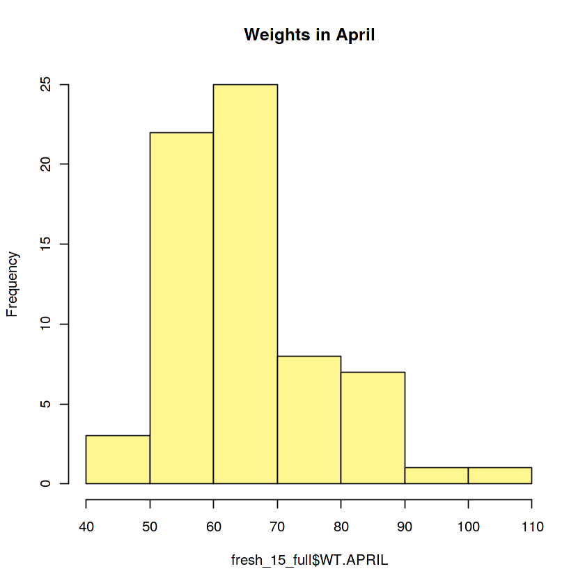

```r
# Histogram of "WT APRIL"
hist(fresh_15_full$"WT.APRIL", col="khaki1", main="Weights in April")
```

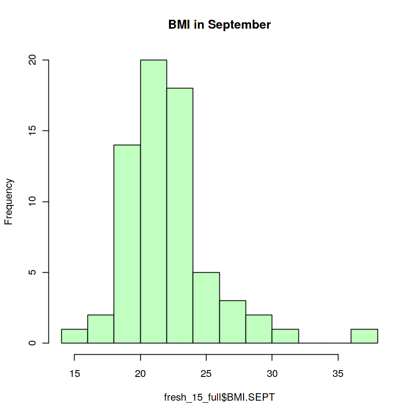

```r
# Histogram of "BMI SEPT"
hist(fresh_15_full$"BMI.SEPT", col="darkseagreen1", main="BMI in September")
```

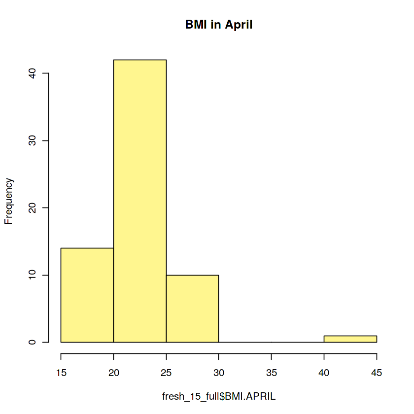

```r
# Histogram of "BMI APRIL"
hist(fresh_15_full$"BMI.APRIL", col="khaki1", main="BMI in April")
```

# Problem 7

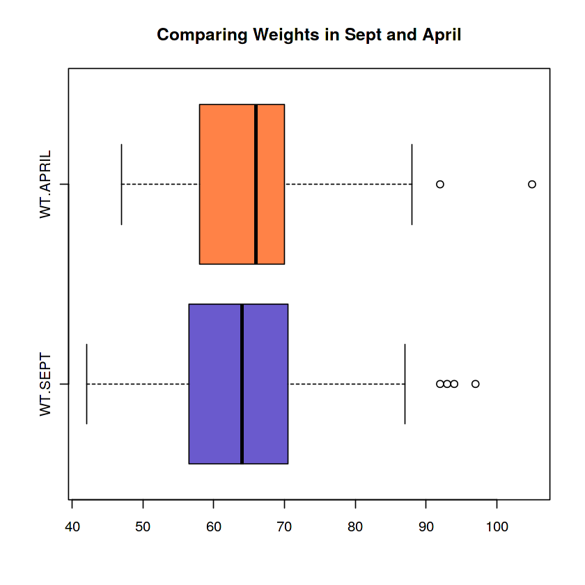

```r
# box plot
# compare before and after freshman year weights
boxplot(fresh_15_full[,c(2,3)], horizontal=TRUE, col=c("slateblue","sienna1"), main="Comparing Weights in Sept and April")
```

```r
# computes 5# Summary statistics for WT.SEPT and WT.APRIL
summary(fresh_15_full[,c(2,3)])
```

```
    WT.SEPT         WT.APRIL
 Min.   :42.00   Min.   : 47.00
 1st Qu.:56.50   1st Qu.: 58.00
 Median :64.00   Median : 66.00
 Mean   :65.06   Mean   : 66.24
 3rd Qu.:70.50   3rd Qu.: 70.00
 Max.   :97.00   Max.   :105.00
```

No, I do not believe in the "freshman 15" myth is accurate. If it was, we would explect to see the majority of the data values in the weights in April to be 15 pounds larger than in September. By comparing the medians, we see that the median weights of students in April went up to 66.00 lbs compared to 64.00 lbs. However, this is only a 2 pound increase. Even the largest weight of 97 pounds increased to 105 lbs, which is only a 8 pound increase.

By looking at the box plots, we see that the weights in April are only slightly larger than in September.

In conclusion, we the "freshman 15" myth doesn't apply--at least to this data set!

# Problem 8

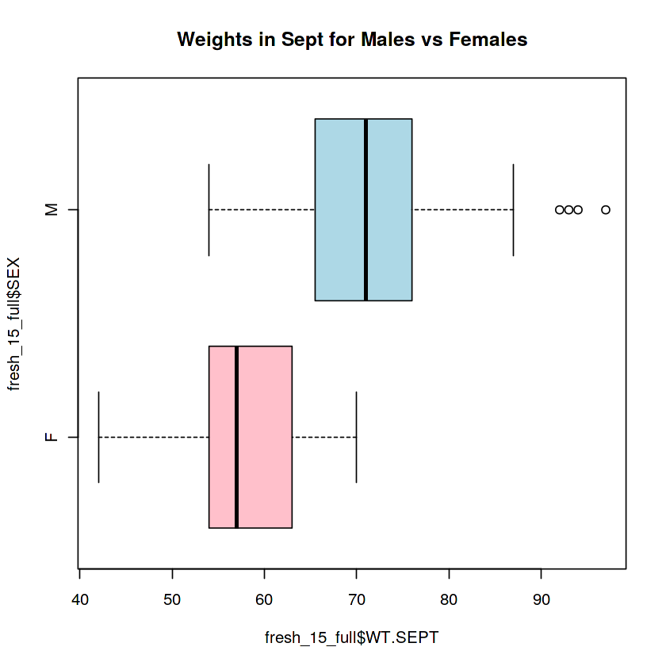

```r
# box plot
# compare two box plots between M vs F
# first piece before the tilde (~) is the box plots from the "WT SEPT" column
# the second after the tilde (~) is the grouping variable (SEX, M/F)
boxplot(fresh_15_full$"WT.SEPT" ~ fresh_15_full$SEX, horizontal=TRUE, col=c("pink", "lightblue"), main="Weights in Sept for Males vs Females")
```

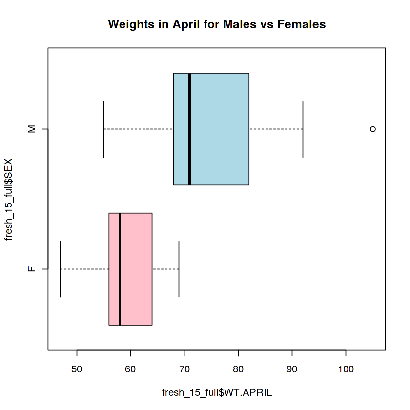

```r
# box plot
# compare two box plots between M vs F
# first piece before the tilde (~) is the box plots from the "WT APRIL" column
# the second after the tilde (~) is the grouping variable (SEX, M/F)
boxplot(fresh_15_full$"WT.APRIL" ~ fresh_15_full$SEX, horizontal=TRUE, col=c("pink", "lightblue"), main="Weights in April for Males vs Females")
```

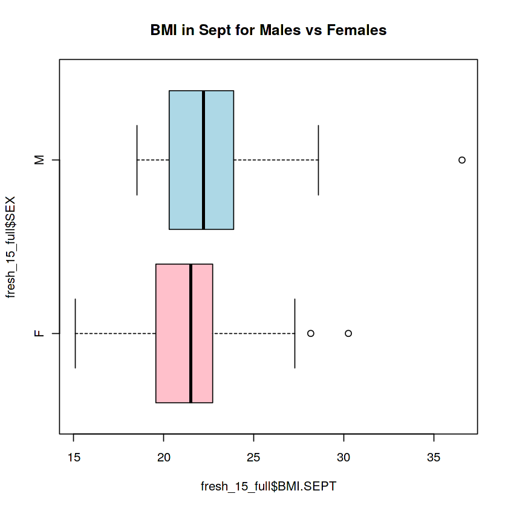

```r
# box plot
# compare two box plots between M vs F
# first piece before the tilde (~) is the box plots from the "BMI SEPT" column
# the second after the tilde (~) is the grouping variable (SEX, M/F)
boxplot(fresh_15_full$"BMI.SEPT" ~ fresh_15_full$SEX, horizontal=TRUE, col=c("pink", "lightblue"), main="BMI in Sept for Males vs Females")
```

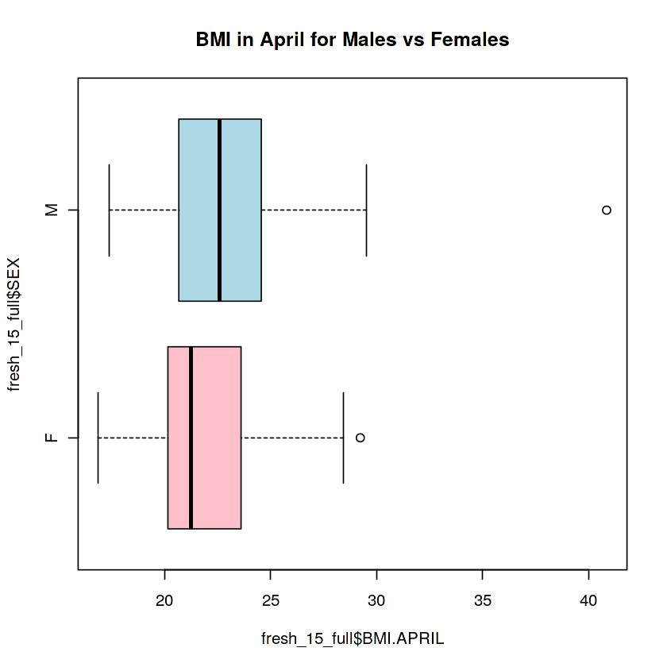

```r
# box plot
# compare two box plots between M vs F
# first piece before the tilde (~) is the box plots from the "BMI APRIL" column
# the second after the tilde (~) is the grouping variable (SEX, M/F)
boxplot(fresh_15_full$"BMI.APRIL" ~ fresh_15_full$SEX, horizontal=TRUE, col=c("pink", "lightblue"), main="BMI in April for Males vs Females")
```

## Problem 8, part a

No, the freshman 15 myth is still not true even if we only look at males. Their weights go up but not by 15 lbs.

## Problem 8, part b

No, the freshman 15 myth is still not true even if we only look at females. Their weights go up but not by 15 lbs.

# END OF LAB 2 !!!!